# Josh Nugent, PhD

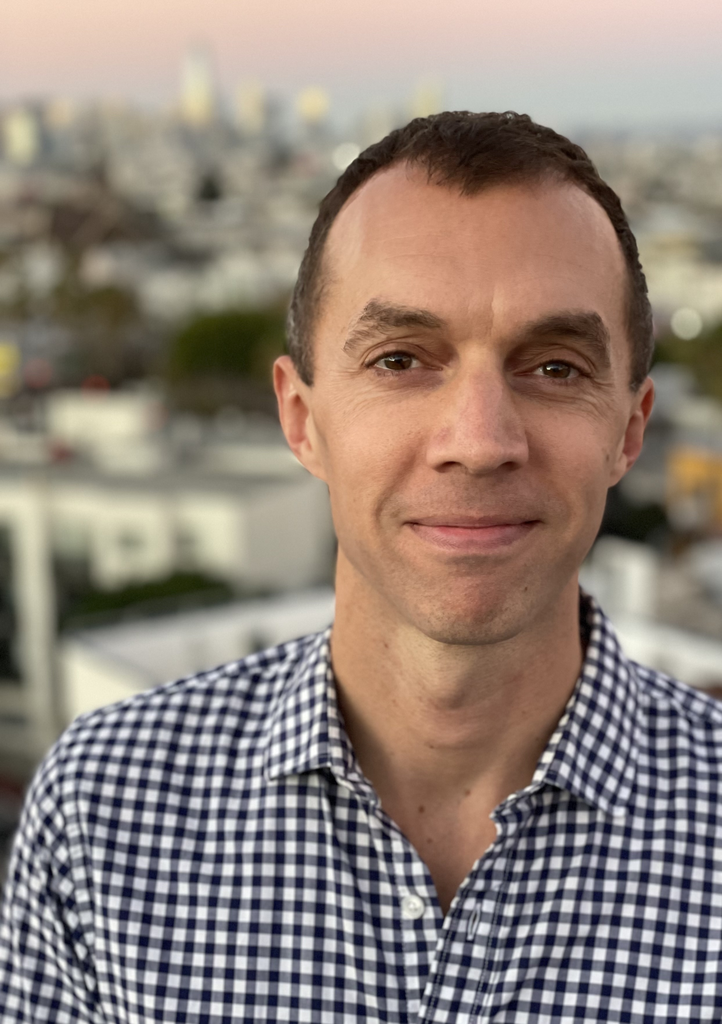

Biostatistician at the [Kaiser Permanente Division of Research](https://divisionofresearch.kaiserpermanente.org/researchers/nugent-joshua) focusing on causal inference, machine learning, and clustered data. Before earning my doctorate (advised by [Laura Balzer](https://www.balzerlab.com/)), I was a high school math teacher for 8 years, among other things. I have also worked frequently with the [SEARCH Collaboration](https://www.searchendaids.com/), evaluating impacts of various interventions to reduce infectious disease burden in Kenya and Uganda.

### Research interests & expertise:

- Causal inference with applications to public health, medicine, and public policy
- Semiparametric statistics with discrete or continuous exposures
- Integrating (ensemble) machine learning and statistical inference via targeted learning
- Design and analysis of randomized trials, particularly with small samples and complex dependence structures
- Interpretation and communication of statistical results
- Teaching statistical concepts
- Anti-racism, equity, inclusion, social justice, conflict resolution

### Publications

Please see my [Google Scholar profile](https://scholar.google.com/citations?user=WGw7LVEAAAAJ&hl=en) for the most up-to-date publication list.

### Informal projects, explainers, experiments, visualizations, etc…

- Inspired by the recent arrival of a nephew, an analysis of state-level patterns in newborn names and future name popularity prediction. [Summary of some 2020 findings](http://joshua-nugent.github.io/newborn_names) and [Shiny app in development](https://joshuanugent.shinyapps.io/babynames/) to explore the data.
- [Vignette](https://joshua-nugent.github.io/allFit/) on adjusting settings, trying different optimizers, and/or using the allFit() function to help achieve convergence in lmer/glmer mixed models. At least one person (not me) has used this to save their dissertation research from failure!